# Homework #01

SMDS-2022-2023

M.Sc. in Data Science

## A. Simulation

### 1. Consider the following joint discrete distribution of a random vector $(Y,Z)$ taking values over the bi-variate space:

$$\begin{eqnarray*}
{\cal S} = {\cal Y} \times {\cal Z} &=& \{(1,1);(1,2);(1,3);\\
&& (2,1);(2,2);(2,3);\\
&& (3,1);(3,2);(3,3)\}
\end{eqnarray*}$$
The joint probability distribution is provided as a matrix $\texttt{J}$ whose generic entry $\texttt{J[y,z]}=Pr \{Y=y,Z=z\}$

```r
J
```

```
     1    2    3
1 0.06 0.17 0.10
2 0.10 0.12 0.11
3 0.14 0.02 0.18
```

```r
S
```

```
      row col
(1,1)   1   1
(1,2)   1   2
(1,3)   1   3
(2,1)   2   1
(2,2)   2   2
(2,3)   2   3
(3,1)   3   1
(3,2)   3   2
(3,3)   3   3
```

You can load the matrix `S` of all the couples of the states in ${\cal S}$ and the matrix `J` containing the corresponding bivariate probability masses from the file “Hmwk.RData”. How can you check that $J$ is a probability distribution?

The joint distribution represented in the matrix `J` is a discrete distribution with 9 probability massess $p_{yz}$ with $y \in \{1,2,3\}$ and $z \in \{1,2,3\}$ assigned to each point of the support which is in turn made of couples of components $(y,z) \in \cal S$. In order to check that J is a probability distribution it suffices to check that the 9 masses are non negative and they all sum up to 1. We can do that with the following `R` code. For the non-negativity we can use the following

```r
#we have to check if all the numbers are >= 0.
J>=0
```

```
     1    2    3
1 TRUE TRUE TRUE
2 TRUE TRUE TRUE
3 TRUE TRUE TRUE
```

```r
sum(J) # to checl if the sum it's equal to 1
```

```
[1] 1
```

### 2. How many *conditional distributions* can be derived from the joint distribution `J`? Please list and derive them.

: Having the variables Z and Y, we can get the conditional distribution of Z on Y values and Y on Z values. So We can obtain 6 conditional distribution from J (the joint distribution). And to obtain the marginal we have to do the ration between the distributions from the probability mass and the sum of the row or column.

```r
# we can get 6 conditional distribution from this:
conditional_sum <- nrow(J)+ncol(J)
conditional_sum
```

```
[1] 6
```

```r
marginal_of_Z <- apply(J,2,sum)
marginal_of_Y <- apply(J,1,sum)
marginal_of_Z
```

```
   1    2    3
0.30 0.31 0.39
```

```r
marginal_of_Y
```

```
   1    2    3
0.33 0.33 0.34
```

```r
conditional_of_Y_given_Z <- J/matrix(marginal_of_Z,nrow=3,ncol=3,byrow=TRUE)
conditional_of_Y_given_Z
```

```
          1          2         3
1 0.2000000 0.54838710 0.2564103
2 0.3333333 0.38709677 0.2820513
3 0.4666667 0.06451613 0.4615385
```

```r
conditional_of_Z_given_Y <- J/matrix(marginal_of_Y,nrow=3,ncol=3,byrow=TRUE)
conditional_of_Z_given_Y
```

```
          1          2         3
1 0.1818182 0.51515152 0.2941176
2 0.3030303 0.36363636 0.3235294
3 0.4242424 0.06060606 0.5294118
```

### 3. Make sure they are probability distributions.

```r
conditional_of_Y_given_Z>=0
```

```
     1    2    3
1 TRUE TRUE TRUE
2 TRUE TRUE TRUE
3 TRUE TRUE TRUE
```

```r
conditional_of_Z_given_Y>=0
```

```
     1    2    3
1 TRUE TRUE TRUE
2 TRUE TRUE TRUE
3 TRUE TRUE TRUE
```

```r
sum(conditional_of_Y_given_Z)
```

```
[1] 3
```

```r
sum(conditional_of_Z_given_Y)
```

```
[1] 2.995544
```

### 4. Can you simulate from this `J` distribution? Please write down a working procedure with few lines of R code as an example. Can you conceive an alternative approach? In case write down an alternative working procedure with few lines of R

Here we can notice if M get bigger, the sampling probability goes closer to true.

```r
combinations <- rownames(S)
combinations
```

```
[1] "(1,1)" "(1,2)" "(1,3)" "(2,1)" "(2,2)" "(2,3)" "(3,1)"
[8] "(3,2)" "(3,3)"
```

```r
set.seed(123)
```

```r
size <- 1000
prob<-c(J[1,], J[2,], J[3,])
table(sample(combinations,size,prob,replace = TRUE))
```

```
(1,1) (1,2) (1,3) (2,1) (2,2) (2,3) (3,1) (3,2) (3,3)
   53   160   108    97   111   112   152    19   188
```

```r
prop.table(table(sample(combinations,size,prob,replace = TRUE)))
```

```
(1,1) (1,2) (1,3) (2,1) (2,2) (2,3) (3,1) (3,2) (3,3)
0.053 0.163 0.107 0.095 0.129 0.099 0.154 0.024 0.176
```

```r
size <- 1000000
table(sample(combinations,size,prob,replace = TRUE))
```

```
 (1,1)  (1,2)  (1,3)  (2,1)  (2,2)  (2,3)  (3,1)  (3,2)
 60137 169847  99691  99985 119841 109709 140184  19813
 (3,3)
180793
```

```r
prop.table(table(sample(combinations,size,prob,replace = TRUE)))
```

```
   (1,1)    (1,2)    (1,3)    (2,1)    (2,2)    (2,3)
0.059801 0.169804 0.100217 0.100353 0.120699 0.109959
   (3,1)    (3,2)    (3,3)
0.139857 0.019821 0.179489
```

## B. Bulb lifetime: a conjugate Bayesian analysis of exponential data

Based on your experience with light bulbs, you believe that their lifetimes $Y_i$ can be modeled using an exponential distribution conditionally on $\theta$ where $\psi = 1/\theta$ is the average bulb lifetime.

### 1. Write the main ingredients of the Bayesian model.

The key ingredients to a Bayesian analysis are the likelihood function, which reflects information about the parameters contained in the data, and the prior distribution, which quantifies what is known about the parameters before observing data.

### 2. Choose a conjugate prior distribution $\pi(\theta)$ with mean equal to 0.003 and standard deviation 0.00173.

```r
alpha=3.007
beta =1002.372
```

### 3. Argue why with this choice you are providing only a vague prior opinion on the average lifetime of the bulb.

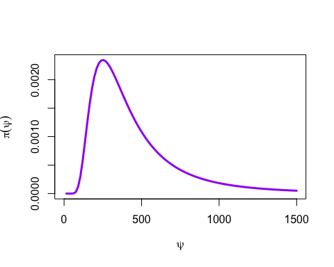

```r
library(TeachingDemos)
# the average lifetime of the bulb is the inverse of the Gamma.
alpha =3.007
beta =1002.372
library(invgamma)
curve(dinvgamma(x,shape = alpha,rate= beta), from=0,to=1500, lwd=3,col="purple", xlab=expression(psi),ylab=expression(pi(psi)))
```

Calculationg the prior qualtiles:

```r
quantiles_prior= qinvgamma(p=c(0.025,0.975),shape=alpha,rate=beta)
quantiles_prior
```

```
[1]  138.5296 1612.3286
```

### 4. Show that this setup fits into the framework of the conjugate Bayesian analysis.

To obtain the distribution of f(theta|y), we have to multiply the distribution of f($\theta$) by f($y_i|theta$). The distribution of f($\theta$) is a Gamma, while the distribution of f($y_i|theta$) is an Exponential. By doing this, we obtain a Gamma distribution for f($\theta|y$) with updated parameters. These parameters are determined by adding up all the $y_i$ values from 1 to n to get the sum of $y_i$. The alpha parameter is then updated by adding n to the previous alpha value, while the beta parameter is updated by adding the sum of $y_i$ to the previous beta value.

```r
y=c(1, 13, 27, 43, 73, 75, 154, 196, 220,
        297, 344, 610, 734, 783, 796, 845,
        859, 992, 1066, 1471)
n=length(y)
sum_y=sum(y)
alpha_star=alpha+n
beta_star=beta+sum_y
```

### 5. Based on the information gathered on the 20 bulbs, what can you say about the main characteristics of the lifetime of your innovative bulb? Argue that we have learnt some relevant information about the $\theta$ parameter and this can be converted into relevant information about the unknown average lifetime of the innovative bulb $\psi=1/\theta$.

Now we are calculating the 95% with alpha_star and beta_star, knowing that alpha_star= alpha+n and beta_star = beta+ summation(yi) with i=1…n

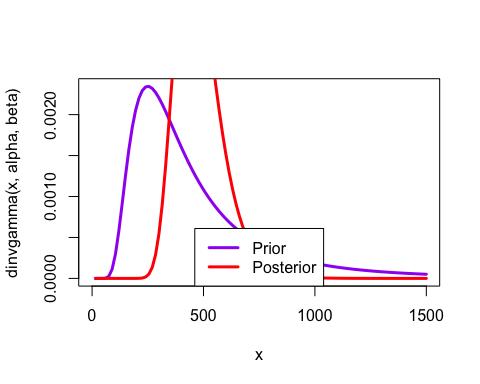

```r
curve(dinvgamma(x, alpha, beta),from=0,to=1500,lwd= 3,col="purple")
curve(dinvgamma(x, alpha_star, beta_star),from = 0,to = 1500,lwd=3, col="red",add=TRUE)
legend("bottom", legend=c("Prior", "Posterior"), lwd = 3, col=c("purple","red"))
```

```r
quantiles_post = qinvgamma(p=c(0.025,0.975),shape=alpha_star,rate=beta_star)
quantiles_post
```

```
[1] 318.1999 726.8386
```

```r
mean(y)
```

```
[1] 479.95
```

```r
prior_prob=pgamma(q=1/550,shape=alpha,rate=beta)
prior_prob
```

```
[1] 0.273882
```

```r
post_prob=pgamma(q=1/550,shape=alpha_star,rate=beta_star)
post_prob
```

```
[1] 0.2254192
```

## C. Exchangeability

Let us consider an infinitely exchangeable sequence of binary random variables $X_1,...,X_n,...$

### 1. Provide the definition of the distributional properties characterizing an infinitely echangeable binary sequence of random variables $X_1, ...,X_n, ....$. Consider the De Finetti representation theorem relying on a suitable distribution $\pi(\theta)$ on $[0,1]$ and show that

$$\begin{eqnarray*}
E[X_i]&=&E_{\pi}[\theta]\\
E[X_i X_j] &=& E_{\pi}[\theta^2]\\
Cov[X_i X_j] &=& Var_{\pi}[\theta]
\end{eqnarray*}$$

$E[X_i]$=$E_{\pi}[\theta]$

The De Finetti representation theorem states that any exchangeable sequence of binary random variables {X_1, X_2, …, X_n} can be modeled as conditionally independent Bernoulli trials with a random probability parameter theta, and theta is distributes as pi(theta). Then $Xn->\theta~\pi(\theta)$. Considering $p(X1, X2, ... Xn)$ = $\int∏pi^Xi(1-pi)^(1-Xi)dpi$, then $E[X1]$ =$\int\prod\pi^Xi(1-pi)^(1-Xi)p(pi)dpi$, (to semplify I wrote “$\pi(\theta)$” as “$\pi$”) where the product converges almost surely to the mixing distribution pi, so : E[X1] = $\int\pi p(pi)dpi$ the expected value of the mixing distribution pi: $E[X] = E[\pi]$

$E[X_i X_j]=E_{\pi}[\theta^2]$

We can use the law of total probability and the fact that XiXj is a Bernoulli product: $E[XiXj]$ = $E[E[XiXj|\theta]] = E[\theta^2]$ where the second equality follows from the fact that $E[XiXj|θ] = \theta^2$ then using the law of total expectation : $E[\theta^2] = Eπ[E[\theta^2|\theta]] = Eπ[\theta^2]$ $E[XiXj]$ equals the expected value of $\theta^2$ under the mixing distribution $\pi(\theta)$.

$Cov[X_i X_j]=Var_{\pi}[\theta]$ $Cov[Xi,Xj] = E[Xi,Xj] - E[Xi]E[Xj]$ and from the De Finetti representation, we have $E[X_i,X_j] = E[X_i]E[X_j]$ Since $\mu_\theta$ is a product measure.Therefore, $Cov[X_i, X_j] = 0$ and $Var_\pi[\theta] = E[X_i^2] - E[X_i]^2$. $X_i$ has the same distribution by exchangeability, $Var_\pi[\theta] = Var(X_i)$ so $Cov[X_i, X_j] = 0$ and $Var_pi[theta] = Var(X_i)$ the covariance between any two variables is zero and the variance of theta characterizes the common distribution of the infinitely exchangeable sequence.

### 2. Prove that any couple of random variabes in that sequence must be non-negatively correlated.

If we randomly permute the indices of any finite subset of the sequence,the resulting probability distribution is the same as the original. To prove that they are non-negatively correlated, i.e., $Cov(X_i, X_j)$ is greater than or equal to zero $Cov(X_i, X_j) = E[(X_i - E[X_i])(X_j - E[X_j])]$ Assuming $p = P(X_1 = 1)$ and $q = P(X_2 = 1)$ Then we can write: $E[X_1] = p$, $E[X_2] = q$, and $E[X_1X_2]=pq + (1-p)(1-q)$. So: $Cov(X_1, X_2) = (1-p)(1-q), 0<=(1-p)(1-q)<=1$. $Cov(X_1, X_2)$ is non-negative.

### 3. Find what are the conditions on the distribution $\pi(\cdot)$ so that $Cor[X_i X_j]=1$.

$Cor[Xi Xj] = Cov[Xi Xj]/\sqrt{(Var(Xi)Var(Xj))}=1$ to have this $Cov[Xi Xj]$ = $\sqrt{(Var(Xi)Var(Xj))}$, and knowing that $Xi$ and $Xj$ are $id$, we just need $Cov[Xi Xj] = Var(Xi)$

### 4. What do these conditions imply on the type and shape of $\pi(\cdot)$? (make an example).

An example can be the Bernoulli distribution, where we have the probability p that can assume values as 0 and 1.

© 2022-2023 - Statistical Methods in Data Science and Laboratory II - 2022-2023

```
Last update by LT: Thu Apr 20 11:51:38 2023
```